# Autonomous Portfolio Lookup Agent with Computer-Using Agents (CUA)

Build an autonomous Copilot Studio agent that retrieves financial portfolio data from internal legacy systems that lack API connectivity.

## Lab Details

[output not shown]

## Table of Contents

- Why This Matters
- Introduction
- Core Concepts Overview
- Documentation and Additional Training Links
- Prerequisites
- Summary of Targets
- Use Cases Covered
- Instructions by Use Case
  - Use Case #1: Create and Configure an Autonomous Agent
  - Use Case #2: Add Computer Use and Email Connector

## Why This Matters

Legacy systems without APIs create major roadblocks for automation. Traditional RPA often relies on fragile screen-scraping or manual workarounds, which slow down decision-making, increase errors, and reduce productivity.

This lab introduces Microsoft Copilot Studio and Computer Using Agents (CUA) as a smarter solution. By simulating human interaction with internal systems, CUAs can securely access and process data - without needing API integration. You’ll learn to build an autonomous agent that delivers faster responses, reduces manual workload, and enables real-time, informed decisions.

## Introduction

In this lab, you’ll learn how to build an autonomous agent using Microsoft Copilot Studio. This agent will simulate human interaction with a legacy internal system to retrieve financial portfolio data without requiring direct API access.

**Real-world example:** A financial advisor needs quick access to key portfolio details - such as client name, portfolio value, and assigned manager - to prepare for meetings, review performance, resolve issues, or recommend rebalancing. However, this data resides in a legacy system that lacks an API and is restricted from direct access.

Traditional RPA tools may fall short in such scenarios. They rely on fragile screen-scraping and require constant maintenance, making them unreliable and costly for dynamic, real-time use cases.

As a result, advisors must depend on back-office teams to retrieve information, causing delays, inefficiencies, and a higher risk of errors - ultimately limiting their ability to make timely, informed decisions.

By implementing a Copilot Studio agent, advisors can securely and instantly retrieve accurate portfolio data. This improves response times, reduces manual workload, and enhances overall productivity without the limitations of traditional RPA.

## Core Concepts Overview

[output not shown]

## Documentation and Additional Training Links

- [Microsoft Copilot Studio Documentation](https://learn.microsoft.com/microsoft-copilot-studio/)
- [Copilot Studio Triggers](https://learn.microsoft.com/microsoft-copilot-studio/authoring-triggers-about)
- [Use connectors in Copilot Studio](https://learn.microsoft.com/microsoft-copilot-studio/advanced-connectors)
- [Office 365 Outlook Connector](https://learn.microsoft.com/connectors/office365/)
- [Automate web and desktop apps with computer use](https://learn.microsoft.com/microsoft-copilot-studio/computer-use)

## Prerequisites

- Access to Microsoft Copilot Studio with appropriate licensing
- Office 365 environment with Outlook integration enabled

## Summary of Targets

In this lab, you’ll build an autonomous portfolio lookup agent that retrieves portfolio information from an internal legacy system. By the end of the lab, you will:

- Create and configure an autonomous agent with email triggers for automatic activation
- Add a Computer use tool to simulate the process of a human user retrieving information from a website by logging into a computer, navigating through the website’s graphical user interface, performing searches, and extracting the required data
- Configure email response tools that reply professionally with proper formatting
- Test the complete workflow with realistic scenarios and various requests

## Use Cases Covered

[output not shown]

## Use Case #1: Create and Configure an Autonomous Agent

Set up the foundational autonomous agent with email triggers that automatically activates when email requests arrive.

[output not shown]

**Summary of tasks**

You will create a new autonomous agent in Microsoft Copilot Studio, configure its identity, and set up an email trigger using the Microsoft 365 Outlook connector.

**Scenario:** To automate portfolio lookups, the agent must be able to detect incoming email requests and initiate the appropriate automation flow based on subject line filtering.

### Objective

Learn how to create and configure an autonomous agent that listens for specific email triggers and prepares to launch automation tasks in response.

### Step-by-step instructions

#### Creating the agent and trigger setup

1. Navigate to copilotstudio.microsoft.com
2. Make sure you’re in the correct environment by looking at the top right corner. In these labs, the environment name should start with **DEV -**
3. Go to the **Solutions** menu (located in the left-hand menu under the ellipsis `...`)
4. Select the solution you had created previously for your labs
5. Select **New** and choose **Agent**
6. Select **Configure** to bypass the initial setup wizard
7. Name your agent `Portfolio Lookup Agent`
8. Select **Create**

#### Configuring email triggers

9. Scroll down to the triggers section and click **+Add trigger**
10. Search and select `When a new email arrives (V3) (Office 365 Outlook)`
11. Select **Next**
12. Rename the trigger to `When a portfolio lookup email arrives`
13. Select **Next**
14. In the **Subject Filter (Optional)** field, enter `Portfolio` to filter emails that contain the word Portfolio in the subject line
15. Finally **Create trigger**

### Congratulations! You’ve completed Use Case #1!

## Use Case #2: Add Computer Use and Email Connector

Configure a Computer use tool that logs into a computer, navigates through a website, searches and retrieves financial portfolio data. Then use the Office 365 Outlook connector to reply with the requested data.

[output not shown]

**Summary of tasks**

You will configure the Computer use tool to simulate GUI-based data retrieval, set up the Send an email tool for automated responses, and define the agent’s behavior and testing flow.

**Scenario:** To complete the automation loop, the agent must retrieve portfolio data from a legacy web interface using desktop simulation and respond to email requests with accurate, formatted information.

### Objective

Learn how to integrate and configure tools for desktop automation and email communication, define agent instructions, and test the full end-to-end workflow from trigger to response.

### Step-by-step instructions

#### Configuring the Computer use tool

1. Navigate to **Tools** in the top-level menu
2. Select **+ Add a tool**
3. Select **+ New tool**
4. Select **Computer use**
5. Add the following **Instructions**:

   ```
   1. Go to https://computerusedemos.blob.core.windows.net/web/Portfolio/index.html.
   2. Enter the Portfolio ID in the "Enter Portfolio ID" search field and click on the "Search" button.
   3. Retrieve the "Client Name", "Portfolio Value" and "Manager" values exactly as shown.
   4. Return those three values as the final output.

   If no portfolio data is found, reply that you couldn't find a portfolio with the specified ID.
   ```

6. Keep the box **Use hosted browser** checked to create a connection to the hosted browser
7. Select **Add and configure**
8. Update the **Name** of the Computer use tool as `Look up portfolio data`
9. Update the **Description** as `Search and retrieve financial portfolio data`
10. In the **Inputs** section select **+ Add input**
11. Enter name `Portfolio ID` and description `The ID of the portfolio` and select **Done**

> **Tip:**

> During execution, Computer use combines your instructions with the input values to complete the task.
14. Select **Save**

#### Testing the Computer use tool

15. In the **Instructions** section, select the **Test** button on the right
16. Add the sample value `44123BCD` and select **Test now**
17. Observe the Computer use tool logging into the computer and performing the requested actions:
    - The left panel shows your instructions and a step-by-step log of the tool’s reasoning and actions.
    - The right panel shows a preview of the actions on the machine you set up for computer use.

[figure not shown]

alt text

18. Select **Finish testing**

> **Tip:**

> If the result isn’t what you expect, go to the configuration page and refine your instructions. Add more details to improve accuracy and test again. Allow sufficient time between tests to ensure the previous Computer use task has been fully completed before starting a new one.

#### Setting up email response capabilities

19. Return to the **Tools** tab and select **+ Add a tool**
20. Search for `Send an email (V2) (Office 365 Outlook)` and select it
21. Select **Add and configure**
22. Update its name to `Reply to email`
23. Update the description to: `Use this operation to reply to the email received`
24. Under **Additional details**, set authentication to **Maker-provided credentials**
25. Customize the **To** input and set its **Description** to: `Use the "from" email of the triggering received email.`
26. Customize the **Subject** input and set its **Description** to: `Write the email subject.`
27. Customize the **Body** input and set its **Description** to: `Write the email body using HTML and highlight the requested data.`
28. Click **Save** to finalize the tool configuration

#### Configuring agent instructions and AI settings

29. Navigate to **Overview** tab and then **Edit** the **Instructions**
30. Paste the following comprehensive instructions: `When a financial portfolio related request is received, identify the Portfolio ID and search for the requested data using <Look up portfolio data>. Once you have gathered the financial portfolio information, use the <Reply to email> tool to reply to the original email you received. Do not respond with data beyond what was requested.`

> **Important:**

> For each of the placeholder <…> in the description, use / to insert the tools you just configured in your instructions.

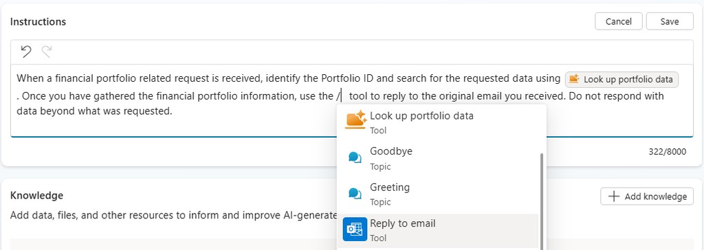

alt text

31. **Save** the instructions
32. Go to the agent’s **Settings**, and in the Knowledge section **disable** the **Use general knowledge** to ground agent responses only to data retrieved from CUA
33. **Save** the settings

#### Testing your complete agent

34. Send a test email from an email address of your preference to your training user’s email account with Subject: `Portfolio data request` and Body:

    ```
    Hi!

    I hope you're doing well!
    I'm looking for the portfolio manager and value of portfolio #44123BCD.

    Much appreciated.
    Thanks!
    ```

35. Make sure you receive the email in your training user’s inbox, in outlook.office.com
36. In the **Overview** tab, go to the **Triggers** section and select **Test trigger**
37. Select the trigger instance and then **Start testing**

[figure not shown]

alt text

38. Check your emails for the agent’s reply.

> **Tip:**
> - Monitor the Computer use tool’s actions in the Test chat window or through the agent’s **Activity** page.
> - In the **Activity** page select the current run and switch from **Activity map** to **Transcript** to get a real-time view of all the steps of the Computer use tool along with their respective screenshots. This view is especially useful in autonomous agent runs.

> **Note:**

> Send an additional email request for another portfolio ID and observe the results.

### Congratulations! You’ve completed Use Case #2!

## Summary of learnings

True learning comes from doing, questioning, and reflecting - so let’s put your skills to the test.

To maximize the impact of autonomous agents for legacy system integration:

- **Use triggers effectively** – Automate business processes based on real-world events
- **Simulate human actions with Computer use** – Enable automation even when APIs are unavailable
- **Integrate communication tools** – Ensure timely, professional responses to user requests
- **Test and iterate** – Continuously refine agent instructions and tool configurations for reliability

### Conclusions and recommendations

**Automation golden rules:**

- Always validate environment and licensing prerequisites before starting
- Use pass-through credentials with caution and document access controls
- Test each automation step independently before full workflow testing
- Monitor agent activity and logs for troubleshooting
- Regularly review and update agent instructions for accuracy
- Document all configurations for future maintenance

By following these principles, you’ll enable secure, scalable, and efficient automation for legacy systems, empowering your organization to make faster, data-driven decisions.